# Zadania_1

Google gemini

2026-03-12

## 1.1 Pearsonov korelacny koeficient

```r
x <- mtcars$hp #horse powers
y <- mtcars$mpg #fuel consumption

# overenie normality
shapiro_hp <- shapiro.test(mtcars$hp)
shapiro_mpg <- shapiro.test(mtcars$mpg)
shapiro_hp
```

```
##
##  Shapiro-Wilk normality test
##
## data:  mtcars$hp
## W = 0.93342, p-value = 0.04881
```

```r
shapiro_mpg
```

```
##
##  Shapiro-Wilk normality test
##
## data:  mtcars$mpg
## W = 0.94756, p-value = 0.1229
```

```r
pearson_corr <- cor(x, y, method = "pearson")
print(pearson_corr)
```

```
## [1] -0.7761684
```

Najprv overujeme ci ide o normalove rozdelenie, to je najlahsie urobit pomocou Sapiro-Vilkovoho testu. P-hodnota pre hp je trochu menej ako 0.05, tu rozdelenie nie je normalne , ale ten rozdiel je maalicky, takze uvazujme ho ako normalne ( asi yo je ok :D). A teda pre mpg p-hodnota urcite vacsie.

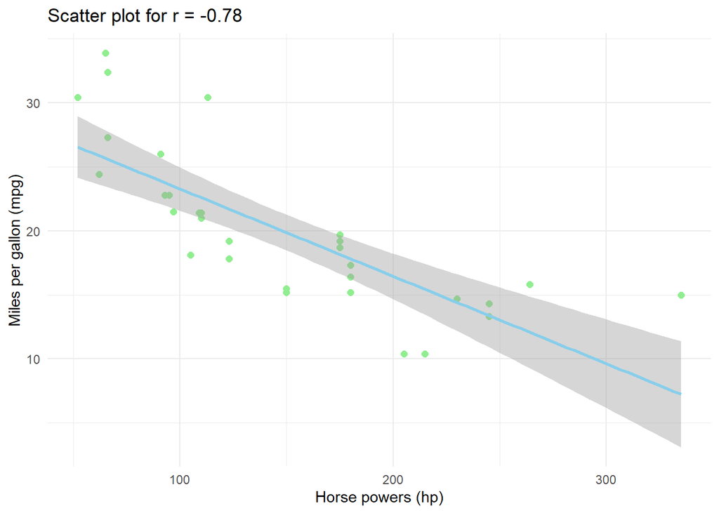

```r
library(ggplot2)
ggplot(mtcars, aes(x = hp, y = mpg)) +
  geom_point(color = "lightgreen", size = 2) +        # Точки
  geom_smooth(method = "lm", col = "skyblue") +     # Лінія регресії (показує тренд)
  labs(title = paste("Scatter plot for r =", round(pearson_corr, 2)),
       x = "Horse powers (hp)",
       y = "Miles per gallon (mpg)") +
  theme_minimal()
```

V tomto pripade je lepsie pouzit Spearmanov koeficient, lebo on je odolnejsi voci odchylkam od normality, mozme vsak aj tento. Mame zaporny korelacny koeficien, a to znamena, ze mame opacnu zavislost premennych. Za abs. hodnotou je to cislo, co sa blizi k 1, teda mame silnu korelaciu.

## 1.2 Test vyznamnosti korelacnoho koeficientu

Teda ci existuje v realnom zivote ten vztah pre vsetky auta? Overujeme hypotezu H0 - korelacia je nulova, H1 - korelacia nie je nulova

```r
test_result <- cor.test(mtcars$hp, mtcars$mpg, method = "pearson")

print(test_result)
```

```
##
##  Pearson's product-moment correlation
##
## data:  mtcars$hp and mtcars$mpg
## t = -6.7424, df = 30, p-value = 1.788e-07
## alternative hypothesis: true correlation is not equal to 0
## 95 percent confidence interval:
##  -0.8852686 -0.5860994
## sample estimates:
##        cor
## -0.7761684
```

P-hodnota je mensia ako 0.05, teda zamietame H0. To znamena, ze je ten vztah statisticky vyznamny.

## 1.3 Spearmanov a Kendallov korelacny koeficient

To su neparametricke metody hladania korelacii. Nie su take citlive na vykidy. Prvy pracuje s rangami matic a hlada hociaky monotonny vztah. Druhy je vhody vacsinou pre male statisticke subory.

```r
x <- mtcars$hp
y <- mtcars$mpg

spearman_corr <- cor(x, y, method = "spearman")
print(paste("Spearman:", round(spearman_corr, 4)))
```

```
## [1] "Spearman: -0.8947"
```

```r
kendall_corr <- cor(x, y, method = "kendall")
print(paste("Kendall:", round(kendall_corr, 4)))
```

```
## [1] "Kendall: -0.7428"
```

Spearmanov v absolutnej hodnote je vacsi ako Kendallov! To znamena, ze zavislost nie je celkom linearna, ona skor pripomina exponencialny pokles. On tu pracuje lepsie.

## 1.4 Korelacna matica

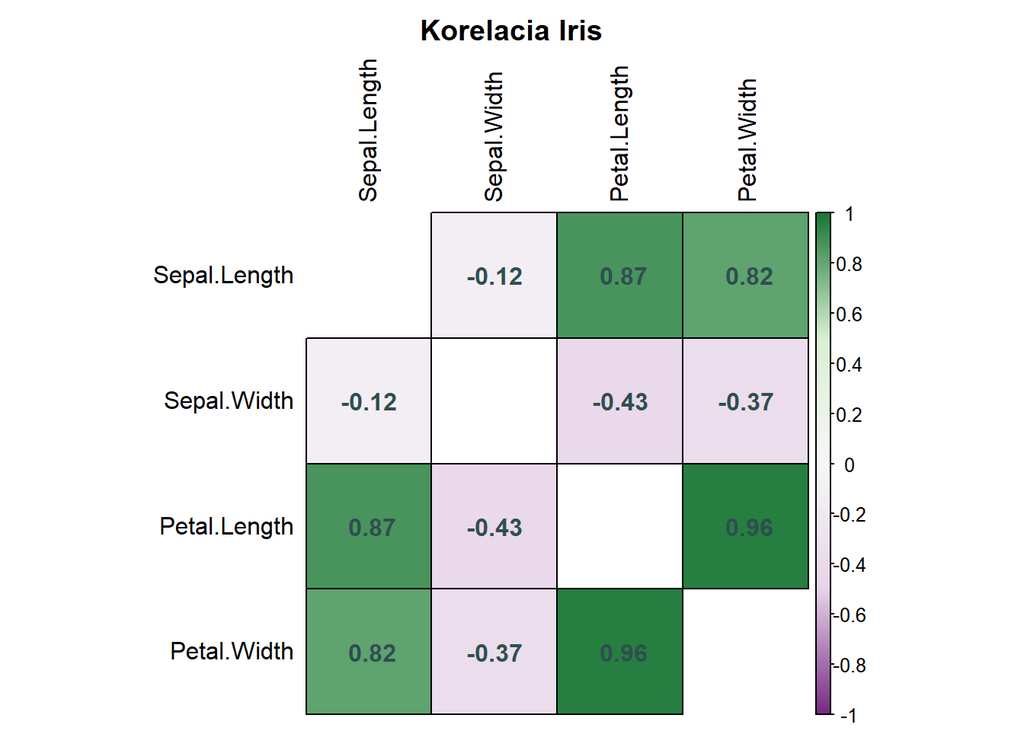

```r
library(corrplot)
m <- cor(iris[, 1:4])

spring_colors <- colorRampPalette(c("#762A83", "#E7D4E8", "#F7F7F7", "#D9F0D3", "#1B7837"))(200)

corrplot(m,
         method = "color",           # stvorceky
         col = spring_colors,        # palitra
         addCoef.col = "#2F4F4F",    # cifry
         tl.col = "black",           # nazvy
         outline = TRUE,             # ramec
         diag = FALSE,               # vynechame diagonalu s jednotkami
         mar = c(0,0,2,0),           # odstupy
         title = "Korelacia Iris")
```

## BONUS Parcialna korelacia

Vypocet korelacii pre mpg a hp s odstranenim vplyvu wt (vaha)

```r
library(ppcor)
# Cista korelacia
result <- pcor.test(mtcars$mpg, mtcars$hp, mtcars$wt)
print(paste("Parcialna korelacia:", round(result$estimate, 3)))
```

```
## [1] "Parcialna korelacia: -0.547"
```

Ked obycajna korelacia je -0.776, a parcialna je menej, tak…

Výkon a spotreba paliva sú veľmi silno prepojené. Vzťah medzi nimi sa však výrazne oslabil, keď sme odstránili vplyv hmotnosti. Výkonné autá sú zvyčajne ťažké a ťažké autá spotrebúvajú viac paliva.